# Effect of Major Historical Events on S&P500 Index

2024-05-01

# Step 0: Understanding the dataset

- “symbol” - The stock symbol of the company in the S&P500 Index.
- “date” - The date of the stock price.
- “open” - The opening price for the specified date(s).
- “high” - The high price for the specified date(s).
- “low” - The low price for the specified date(s).
- “close” - The closing price for the specified date(s).
- “adjusted” - The adjusted closing price for the specified date(s).
- “volume” - The volume for the specified date(s).
- “GICS.Sector” - The Global Industry Classification Standard (GICS) sector of the company.

We are now analyzing how major historical events impacted the S&P 500 index using constituent data in last 23 years, that is from 2000-2024. Specifically, we will:

- Analyze the number of companies in each sector and how they have changed over time.
- Analyze and visualize to understand which GICS sectors drive the S&P500 Index.
- Examine the specific industries of the index respond to the events and how they effected the average price levels of the industry.
- Perform T-tests to compare the average closing prices of the sectors before and after the events.
- Forecast the S&P 500 index using ARIMA and LSTM model to see how effectively the S&P500 Index can be predicted.
- Evaluate the performance of the ARIMA and LSTM models using Mean Absolute Error (MAE), Mean Squared Error (MSE), and Root Mean Squared Error (RMSE).

By looking at prices, returns, correlations, visualizations, and handling outliers, we aim to comprehensively assess how significant historical occurrences influenced the behavior of the S&P 500 index over this 20-year period.

# Step 1: Loading the dataset

```r
datasets.url <- "https://drive.usercontent.google.com/download?id=1BqKbN3FEqNcRXeisOPxR_LB8VcSCh7mE&export=download&authuser=0&confirm=t"
# df <- read.csv("sp500.csv")
df <- read.csv(datasets.url)
df$Date <- as.Date(df$Date)
str(df)
```

```
## 'data.frame':    2710362 obs. of  9 variables:
##  $ Symbol   : chr  "MMM" "MMM" "MMM" "MMM" ...
##  $ Date     : Date, format: "2000-01-03" "2000-01-04" ...
##  $ Open     : num  40.2 38.8 38.1 39.4 42.3 ...
##  $ High     : num  40.3 39.6 40.2 42.9 43.4 ...
##  $ Low      : num  39.3 37.9 38.1 39.4 41.8 ...
##  $ Close    : num  39.5 37.9 39 42.1 43 ...
##  $ Adj.Close: num  17.6 16.9 17.3 18.7 19.1 ...
##  $ Volume   : num  2599386 3245705 4424482 7147057 4905035 ...
##  $ GICS     : chr  "Industrials" "Industrials" "Industrials" "Industrials" ...
```

# Step 2: Data Preprocessing

### Checking for NA values and duplicates

```r
# Checking for missing values
sum(is.na(df))
```

```
## [1] 0
```

- There are 0 missing values in the dataset. This means the dataset is clean and does not require any imputation or removal of data points.

### Dropping unwanted variables extracting numerical variables

```r
# Making GICS code as a factor variable
df$GICS <- as.factor(df$GICS)
# Removing the adjusted column as it is not required for our analysis
newdf <- df %>% select(-c("Adj.Close")) %>%
  arrange(Date) %>% # sorting the data by date
  mutate(daily_returns = (Close - lag(Close)) / lag(Close))

# remove first row to avoid NA values
newdf <- newdf[-1,]
head(newdf)
```

```
##   Symbol       Date  Open  High   Low Close   Volume                   GICS
## 2    AOS 2000-01-03  3.64  3.65  3.57  3.61   113400            Industrials
## 3    ABT 2000-01-03 15.82 16.16 15.60 15.71 10635087            Health Care
## 4   ADBE 2000-01-03 16.81 16.88 16.06 16.39  7384400 Information Technology
## 5    AMD 2000-01-03 14.97 15.59 14.69 15.50  7843200 Information Technology
## 6    AES 2000-01-03 37.38 37.38 35.62 36.25  1334400              Utilities
## 7    AFL 2000-01-03 11.73 11.78 11.08 11.19  2388800             Financials
##   daily_returns
## 2       -0.9084
## 3        3.3467
## 4        0.0432
## 5       -0.0543
## 6        1.3387
## 7       -0.6914
```

```r
str(newdf)
```

```
## 'data.frame':    2710361 obs. of  9 variables:
##  $ Symbol       : chr  "AOS" "ABT" "ADBE" "AMD" ...
##  $ Date         : Date, format: "2000-01-03" "2000-01-03" ...
##  $ Open         : num  3.64 15.82 16.81 14.97 37.38 ...
##  $ High         : num  3.65 16.16 16.88 15.59 37.38 ...
##  $ Low          : num  3.57 15.6 16.06 14.69 35.62 ...
##  $ Close        : num  3.61 15.71 16.39 15.5 36.25 ...
##  $ Volume       : num  113400 10635087 7384400 7843200 1334400 ...
##  $ GICS         : Factor w/ 11 levels "Communication Services",..: 7 6 8 8 11 5 6 9 8 9 ...
##  $ daily_returns: num  -0.9084 3.3467 0.0432 -0.0543 1.3387 ...
```

- As a part of pre-processing, we have removed the “Adj.Close” column from the dataset as it is not required for our analysis.
- We have also sorted the data by date and calculated the daily returns for each observation.
- The GICS column has been converted to a factor variable for better analysis. GICS consists of 11 levels.

```r
# Define the event windows
great_recession_start <- as.Date("2007-12-31")
great_recession_end <- as.Date("2009-06-30")

covid_start <- as.Date("2020-02-03")
lockdown_end <- as.Date("2020-08-31")
covid_end <- as.Date("2023-05-11")

russia_ukraine_start <- as.Date("2022-02-24")
russia_ukraine_end <- Sys.Date()  # Current date

# The Great Recession
df_recession <- df[df$Date >= "2007-12-31" & df$Date <= "2009-06-30", ]

# Covid-19
df_covid <- df[df$Date >= "2020-02-03" & df$Date <= "2023-05-11", ]

# Russia-Ukraine Invasion
df_ukraine <- df[df$Date >= "2022-02-24", ]
```

### Plot to show number of companies in each GICS sector

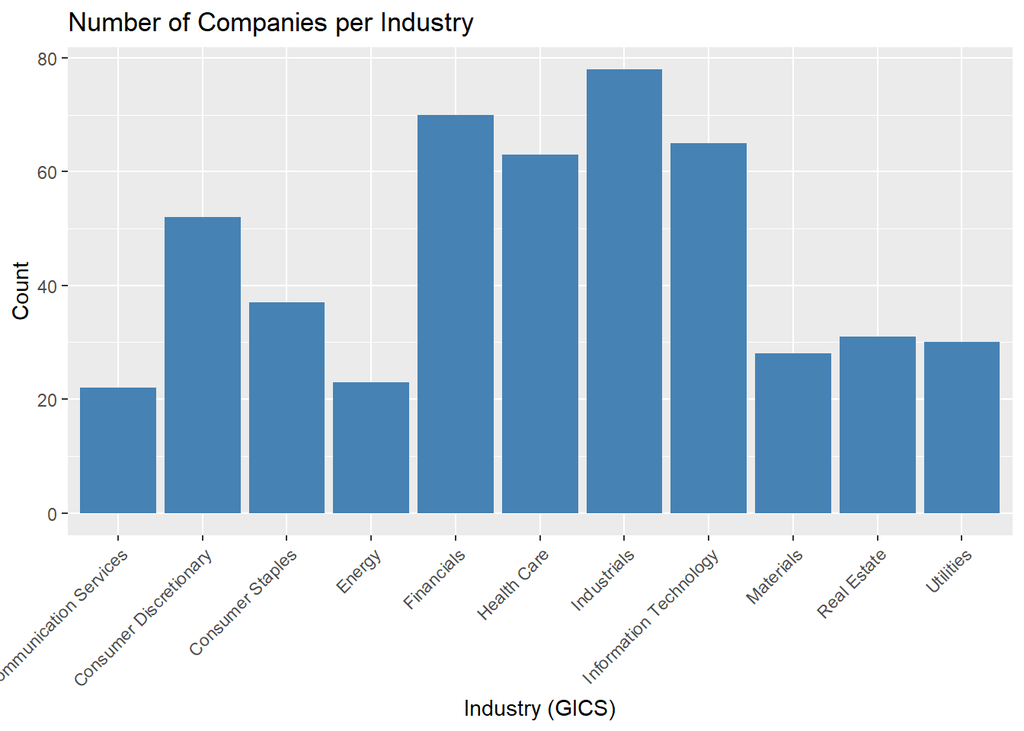

```r
industry_counts <- df %>%
  distinct(Symbol, GICS) %>%
  count(GICS)

ggplot(industry_counts, aes(x = GICS, y = n)) +
  geom_bar(stat = "identity", fill = "steelblue") +
  labs(title = "Number of Companies per Industry", x = "Industry (GICS)", y = "Count") +
  theme(axis.text.x = element_text(angle = 45, hjust = 1))
```

- The bar chart above shows the number of companies in each industry based on the GICS classification.
- The “Industrials” sector has the highest number of companies, followed by “Financials”, and “Information Technology”.

### Stacked Bar Plot to show how S&P500 Companies in the GICS Sectors have changed over time

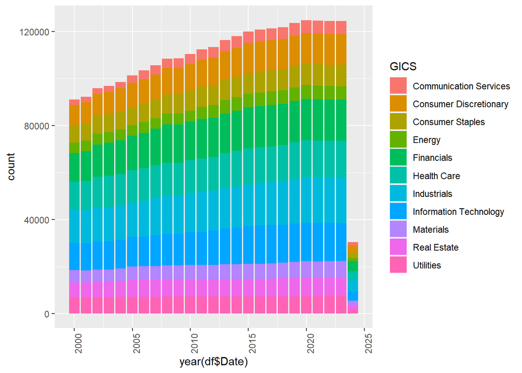

```r
ggplot(df, aes(x = year(df$Date), fill = GICS)) + geom_bar() + theme(axis.text.x = element_text(angle = 90, hjust = 1))
```

- We can observe that the spread of companies across different sectors is relatively concentrated in the following four sectors:
  - Information Technology
  - Financials
  - Health Care
  - Industrials

### Stacked Bar Plot for each year and constituent sector in S&P500 Index with the total traded Volume

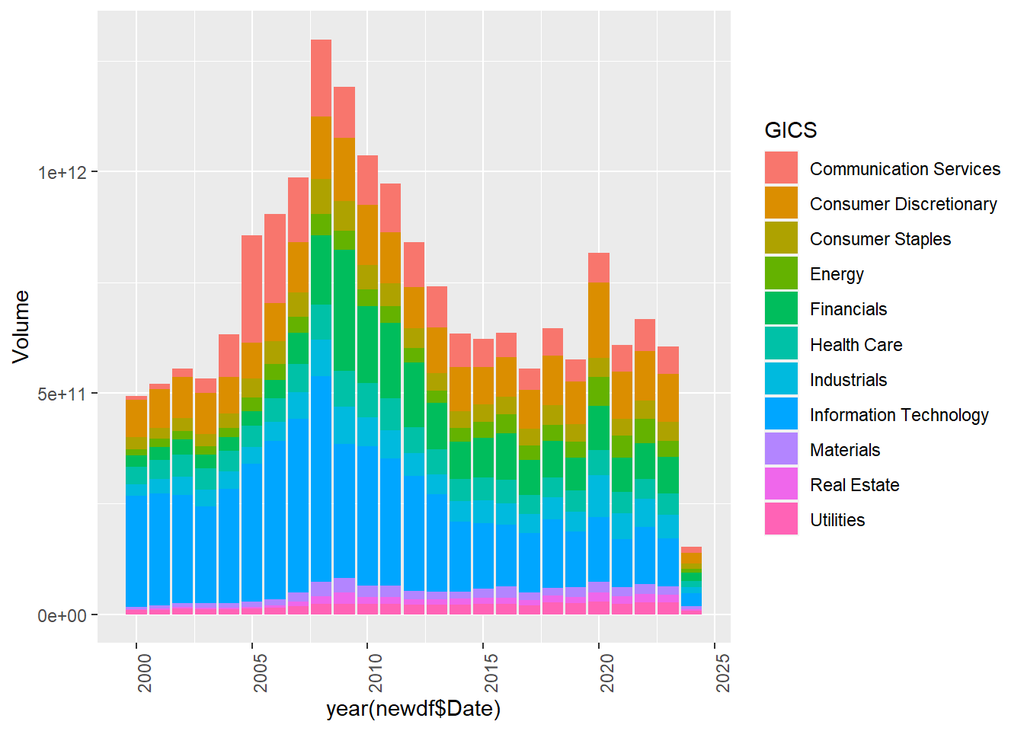

```r
ggplot(newdf, aes(x = year(newdf$Date), y = Volume, fill = GICS)) + geom_bar(stat = "identity") + theme(axis.text.x = element_text(angle = 90, hjust = 1))
```

# SMART Question 1: Are there any specific industries that drive the index?

```r
#checking which industries drive the index
# Fit a linear regression model
model <- lm(Close ~ GICS, data = df)

# Perform an ANOVA test
anova_result <- anova(model)

# Print the ANOVA table
print(anova_result)
```

```
## Analysis of Variance Table
##
## Response: Close
##                Df   Sum Sq  Mean Sq F value Pr(>F)
## GICS           10 1.62e+09 1.62e+08    5938 <2e-16 ***
## Residuals 2710351 7.39e+10 2.73e+04
## ---
## Signif. codes:  0 '***' 0.001 '**' 0.01 '*' 0.05 '.' 0.1 ' ' 1
```

```r
# Alternatively, you can also examine the coefficients
summary(model)
```

```
##
## Call:
## lm(formula = Close ~ GICS, data = df)
##
## Residuals:
##    Min     1Q Median     3Q    Max
##   -140    -52    -28     10   7960
##
## Coefficients:
##                            Estimate Std. Error t value Pr(>|t|)
## (Intercept)                  56.627      0.514  110.07  < 2e-16 ***
## GICSConsumer Discretionary   83.821      0.602  139.17  < 2e-16 ***
## GICSConsumer Staples          0.949      0.631    1.50     0.13
## GICSEnergy                   -5.661      0.694   -8.16  3.5e-16 ***
## GICSFinancials               22.156      0.578   38.33  < 2e-16 ***
## GICSHealth Care              33.142      0.585   56.65  < 2e-16 ***
## GICSIndustrials              19.513      0.576   33.89  < 2e-16 ***
## GICSInformation Technology   16.303      0.585   27.85  < 2e-16 ***
## GICSMaterials                 8.202      0.669   12.25  < 2e-16 ***
## GICSReal Estate              16.488      0.647   25.47  < 2e-16 ***
## GICSUtilities               -14.268      0.649  -21.99  < 2e-16 ***
## ---
## Signif. codes:  0 '***' 0.001 '**' 0.01 '*' 0.05 '.' 0.1 ' ' 1
##
## Residual standard error: 165 on 2710351 degrees of freedom
## Multiple R-squared:  0.0214, Adjusted R-squared:  0.0214
## F-statistic: 5.94e+03 on 10 and 2710351 DF,  p-value: <2e-16
```

- The ANOVA table indicates that the GICS sector has a significant overall effect on the stock’s closing price (p < 2.2e-16).
- The coefficients table shows the estimated effect of each GICS sector on the closing price compared to the baseline category. For example:
- The estimated effect of the Consumer Discretionary sector on the closing price is 83.8207 units higher compared to the baseline.
- The estimated effect of the Energy sector on the closing price is -5.6606 units lower compared to the baseline.

```r
#checking which industries drive the index
# Fit a linear regression model
model1 <- lm(Volume ~ GICS, data = df)

# Perform an ANOVA test
anova_result <- anova(model1)

# Print the ANOVA table
print(anova_result)
```

```
## Analysis of Variance Table
##
## Response: Volume
##                Df   Sum Sq  Mean Sq F value Pr(>F)
## GICS           10 6.79e+19 6.79e+18    6894 <2e-16 ***
## Residuals 2710351 2.67e+21 9.84e+14
## ---
## Signif. codes:  0 '***' 0.001 '**' 0.01 '*' 0.05 '.' 0.1 ' ' 1
```

```r
# Alternatively, you can also examine the coefficients
summary(model1)
```

```
##
## Call:
## lm(formula = Volume ~ GICS, data = df)
##
## Residuals:
##       Min        1Q    Median        3Q       Max
## -2.03e+07 -4.64e+06 -2.22e+06 -2.13e+04  7.41e+09
##
## Coefficients:
##                             Estimate Std. Error t value Pr(>|t|)
## (Intercept)                 20290233      97776   207.5   <2e-16 ***
## GICSConsumer Discretionary -11137284     114467   -97.3   <2e-16 ***
## GICSConsumer Staples       -15171682     119920  -126.5   <2e-16 ***
## GICSEnergy                 -13486290     131921  -102.2   <2e-16 ***
## GICSFinancials             -14706167     109861  -133.9   <2e-16 ***
## GICSHealth Care            -16529389     111192  -148.7   <2e-16 ***
## GICSIndustrials            -17153271     109427  -156.8   <2e-16 ***
## GICSInformation Technology  -4483219     111272   -40.3   <2e-16 ***
## GICSMaterials              -17260865     127195  -135.7   <2e-16 ***
## GICSReal Estate            -18586639     123026  -151.1   <2e-16 ***
## GICSUtilities              -17463429     123318  -141.6   <2e-16 ***
## ---
## Signif. codes:  0 '***' 0.001 '**' 0.01 '*' 0.05 '.' 0.1 ' ' 1
##
## Residual standard error: 31400000 on 2710351 degrees of freedom
## Multiple R-squared:  0.0248, Adjusted R-squared:  0.0248
## F-statistic: 6.89e+03 on 10 and 2710351 DF,  p-value: <2e-16
```

- The ANOVA table indicates that the GICS sector has a significant overall effect on the stock’s volume (p < 2.2e-16).
- The coefficients table shows the estimated effect of each GICS sector on the stock’s volume compared to the baseline category:
- For example, the estimated effect of the Consumer Discretionary sector on the stock’s volume is -11137284 units compared to the baseline.
- The estimated effects for other sectors follow a similar pattern, with each sector having a significant effect on the stock’s volume.

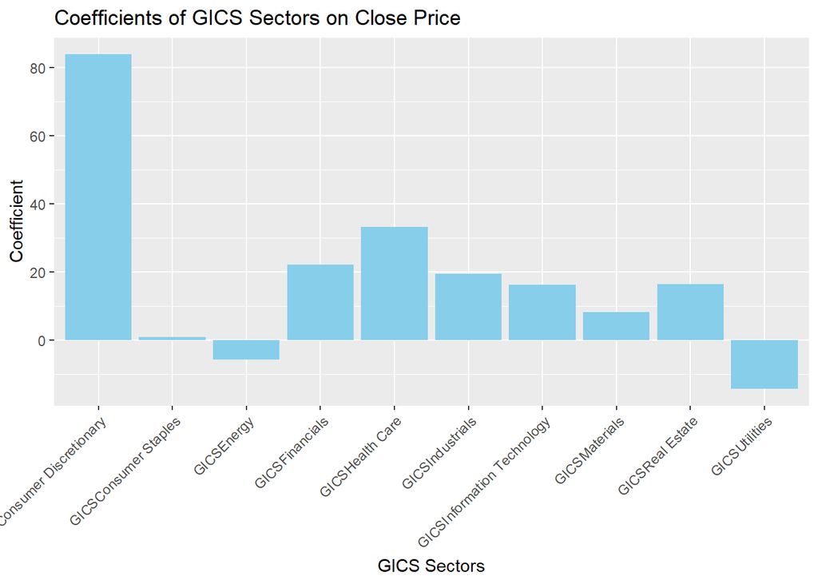

```r
# Create a data frame with coefficients and sectors
coefficients <- coef(model)[-1]  # Exclude intercept
sectors <- names(coefficients)
data <- data.frame(sectors, coefficients)

# Plot
ggplot(data, aes(x = sectors, y = coefficients)) +
  geom_bar(stat = "identity", fill = "skyblue") +
  labs(title = "Coefficients of GICS Sectors on Close Price",
       x = "GICS Sectors",
       y = "Coefficient") +
  theme(axis.text.x = element_text(angle = 45, hjust = 1))
```

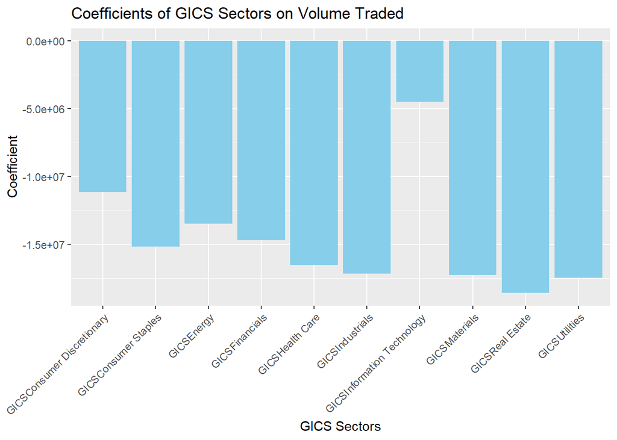

```r
# Create a data frame with coefficients and sectors
coefficients1 <- coef(model1)[-1]  # Exclude intercept
sectors1 <- names(coefficients)
data1 <- data.frame(sectors, coefficients)

# Plot
ggplot(data, aes(x = sectors1, y = coefficients1)) +
  geom_bar(stat = "identity", fill = "skyblue") +
  labs(title = "Coefficients of GICS Sectors on Volume Traded",
       x = "GICS Sectors",
       y = "Coefficient") +
  theme(axis.text.x = element_text(angle = 45, hjust = 1))
```

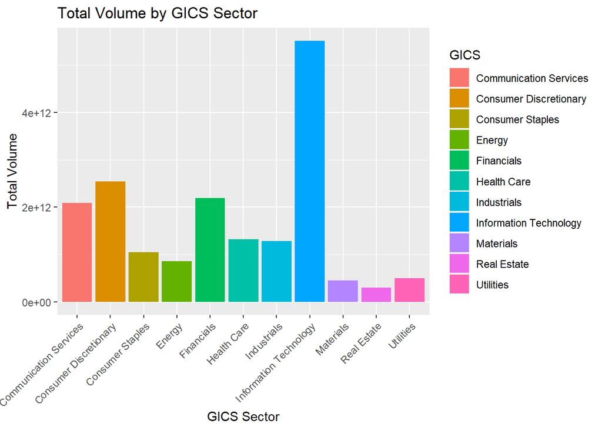

```r
total_volume <- df %>%
  group_by(GICS) %>%
  summarise(total_volume = sum(Volume))

# Bar plot of total volume by GICS sector
ggplot(total_volume, aes(x = GICS, y = total_volume, fill = GICS)) +
  geom_bar(stat = "identity") +
  labs(title = "Total Volume by GICS Sector", x = "GICS Sector", y = "Total Volume") +
  theme(axis.text.x = element_text(angle = 45, hjust = 1))
```

- Here as we can see IT has the highest volume of stocks being traded in the time period, followed by Consumer Discretionary.

# SMART Question 2: How does different GICS Sectors respond to major historical Events

### Defining a function to calculate average returns for each company and then average returns for each GICS sector including the average close price for each company

```r
# Function to calculate returns and average close price for each company and then average returns for each GICS sector
sector_returns <- function(data, start_date, end_date) {
  # Calculate returns for each company and average close price
  company_returns_close <- data %>%
    group_by(Symbol) %>%
    filter(Date >= start_date & Date <= end_date) %>%
    reframe(start_close = Close[Date == start_date],
            end_close = Close[Date == end_date],
            avg_close = mean(Close)) %>%
    mutate(return = (end_close - start_close) / start_close * 100) %>%
    select(Symbol, return, avg_close)

  # Calculate average returns and average close price for each GICS sector
  sector_returns_close <- data %>%
    inner_join(company_returns_close, by = "Symbol") %>%
    group_by(GICS) %>%
    summarize(avg_return = mean(return), avg_close = mean(avg_close))

  return(sector_returns_close)
}

# Calculate sector returns and average close price for each event
recession_returns_close <- sector_returns(df_recession, "2007-12-31", "2009-06-30")
covid_returns_close <- sector_returns(df_covid, "2020-02-03", "2023-05-11")
ukraine_returns_close <- sector_returns(df_ukraine, "2022-02-24", max(df_ukraine$Date))

head(recession_returns_close, 2)
```

```
## # A tibble: 2 × 3
##   GICS                   avg_return avg_close
##   <fct>                       <dbl>     <dbl>
## 1 Communication Services      -33.7      17.5
## 2 Consumer Discretionary      -26.7      39.5
```

```r
head(covid_returns_close, 2)
```

```
## # A tibble: 2 × 3
##   GICS                   avg_return avg_close
##   <fct>                       <dbl>     <dbl>
## 1 Communication Services    -0.0918      114.
## 2 Consumer Discretionary    38.9         316.
```

```r
head(ukraine_returns_close, 2)
```

```
## # A tibble: 2 × 3
##   GICS                   avg_return avg_close
##   <fct>                       <dbl>     <dbl>
## 1 Communication Services      -2.39      101.
## 2 Consumer Discretionary      25.1       373.
```

Subsetting the data for 1 Year before the start of event and after the end of events for T-Tests

```r
year_before_recession <- df[df$Date >= "2006-12-29" & df$Date <= "2007-12-31", ]
year_after_recession <- df[df$Date >= "2009-06-30" & df$Date <= "2010-06-30", ]
year_before_covid <- df[df$Date >= "2019-02-01" & df$Date <= "2020-02-03", ]
# using lockdown end date as the end date for covid
year_after_covid <- df[df$Date >= "2020-08-31" & df$Date <= "2021-08-31", ]
year_before_ukraine <- df[df$Date >= "2021-02-24" & df$Date <= "2022-02-23", ]
year_after_ukraine <- df[df$Date >= "2023-02-24" & df$Date <= "2024-02-24", ]
```

Calculating the average returns for each sector for 1 year before and after the event

```r
# Calculate sector returns for each event and year before and after the event using function defined above
recession_returns_before <- sector_returns(year_before_recession, "2006-12-29", "2007-12-31")
recession_returns_after <- sector_returns(year_after_recession, "2009-06-30", "2010-06-30")
covid_returns_before <- sector_returns(year_before_covid, "2019-02-01", "2020-02-03")
covid_returns_after <- sector_returns(year_after_covid, "2020-08-31", "2021-08-31")
ukraine_returns_before <- sector_returns(year_before_ukraine, "2021-02-24", "2022-02-23")
ukraine_returns_after <- sector_returns(year_after_ukraine, "2022-02-24", "2023-02-24")
```

Create a function to conduct t-tests for each sector before and after the events

```r
sector_ttest <- function(sector, before_data, after_data) {
  subset_before <- before_data %>%
    filter(GICS == sector) %>%
    group_by(Date) %>%
    summarize(avg_close = mean(Close))

  subset_after <- after_data %>%
    filter(GICS == sector) %>%
    group_by(Date) %>%
    summarize(avg_close = mean(Close))

  ttest_result <- t.test(subset_before$avg_close, subset_after$avg_close)

  return(list(before_data = subset_before,
              after_data = subset_after,
              ttest_result = ttest_result))
}
```

### Conduct t-test for “Industrials”, “Information Technology”, “Financials”, “Health Care” sector before and after the Great Recession, Covid-19 Pandemic, and Russia-Ukraine Invasion

```r
industrials_recession <- sector_ttest("Industrials", year_before_recession, year_after_recession)
info_tech_recession <- sector_ttest("Information Technology", year_before_recession, year_after_recession)
financials_recession <- sector_ttest("Financials", year_before_recession, year_after_recession)
health_care_recession <- sector_ttest("Health Care", year_before_recession, year_after_recession)

# Covid-19 Pandemic
industrials_covid <- sector_ttest("Industrials", year_before_covid, year_after_covid)
info_tech_covid <- sector_ttest("Information Technology", year_before_covid, year_after_covid)
financials_covid <- sector_ttest("Financials", year_before_covid, year_after_covid)
health_care_covid <- sector_ttest("Health Care", year_before_covid, year_after_covid)

# Russia-Ukraine Invasion
industrials_ukraine <- sector_ttest("Industrials", year_before_ukraine, year_after_ukraine)
info_tech_ukraine <- sector_ttest("Information Technology", year_before_ukraine, year_after_ukraine)
financials_ukraine <- sector_ttest("Financials", year_before_ukraine, year_after_ukraine)
health_care_ukraine <- sector_ttest("Health Care", year_before_ukraine, year_after_ukraine)


# Printing results of the t-tests for the Great Recession
industrials_recession$ttest_result
```

```
##
##  Welch Two Sample t-test
##
## data:  subset_before$avg_close and subset_after$avg_close
## t = 46, df = 379, p-value <2e-16
## alternative hypothesis: true difference in means is not equal to 0
## 95 percent confidence interval:
##   9.9 10.8
## sample estimates:
## mean of x mean of y
##      44.5      34.1
```

```r
info_tech_recession$ttest_result
```

```
##
##  Welch Two Sample t-test
##
## data:  subset_before$avg_close and subset_after$avg_close
## t = 23, df = 502, p-value <2e-16
## alternative hypothesis: true difference in means is not equal to 0
## 95 percent confidence interval:
##  3.36 3.97
## sample estimates:
## mean of x mean of y
##      30.0      26.3
```

```r
financials_recession$ttest_result
```

```
##
##  Welch Two Sample t-test
##
## data:  subset_before$avg_close and subset_after$avg_close
## t = 134, df = 375, p-value <2e-16
## alternative hypothesis: true difference in means is not equal to 0
## 95 percent confidence interval:
##  43.4 44.7
## sample estimates:
## mean of x mean of y
##      78.9      34.9
```

```r
health_care_recession$ttest_result
```

```
##
##  Welch Two Sample t-test
##
## data:  subset_before$avg_close and subset_after$avg_close
## t = 27, df = 402, p-value <2e-16
## alternative hypothesis: true difference in means is not equal to 0
## 95 percent confidence interval:
##  4.56 5.28
## sample estimates:
## mean of x mean of y
##      39.0      34.1
```

```r
# Printing results of the t-tests for the Covid-19 Pandemic
industrials_covid$ttest_result
```

```
##
##  Welch Two Sample t-test
##
## data:  subset_before$avg_close and subset_after$avg_close
## t = -32, df = 338, p-value <2e-16
## alternative hypothesis: true difference in means is not equal to 0
## 95 percent confidence interval:
##  -34.7 -30.7
## sample estimates:
## mean of x mean of y
##       119       152
```

```r
info_tech_covid$ttest_result
```

```
##
##  Welch Two Sample t-test
##
## data:  subset_before$avg_close and subset_after$avg_close
## t = -49, df = 336, p-value <2e-16
## alternative hypothesis: true difference in means is not equal to 0
## 95 percent confidence interval:
##  -73.2 -67.5
## sample estimates:
## mean of x mean of y
##       113       183
```

```r
financials_covid$ttest_result
```

```
##
##  Welch Two Sample t-test
##
## data:  subset_before$avg_close and subset_after$avg_close
## t = -26, df = 369, p-value <2e-16
## alternative hypothesis: true difference in means is not equal to 0
## 95 percent confidence interval:
##  -30.0 -25.8
## sample estimates:
## mean of x mean of y
##       110       138
```

```r
health_care_covid$ttest_result
```

```
##
##  Welch Two Sample t-test
##
## data:  subset_before$avg_close and subset_after$avg_close
## t = -46, df = 320, p-value <2e-16
## alternative hypothesis: true difference in means is not equal to 0
## 95 percent confidence interval:
##  -72.9 -66.9
## sample estimates:
## mean of x mean of y
##       148       218
```

```r
# Printing results of the t-tests for the Russia-Ukraine Invasion
industrials_ukraine$ttest_result
```

```
##
##  Welch Two Sample t-test
##
## data:  subset_before$avg_close and subset_after$avg_close
## t = -15, df = 406, p-value <2e-16
## alternative hypothesis: true difference in means is not equal to 0
## 95 percent confidence interval:
##  -14.2 -10.9
## sample estimates:
## mean of x mean of y
##       168       180
```

```r
info_tech_ukraine$ttest_result
```

```
##
##  Welch Two Sample t-test
##
## data:  subset_before$avg_close and subset_after$avg_close
## t = -9, df = 425, p-value <2e-16
## alternative hypothesis: true difference in means is not equal to 0
## 95 percent confidence interval:
##  -22.7 -14.8
## sample estimates:
## mean of x mean of y
##       209       228
```

```r
financials_ukraine$ttest_result
```

```
##
##  Welch Two Sample t-test
##
## data:  subset_before$avg_close and subset_after$avg_close
## t = 14, df = 468, p-value <2e-16
## alternative hypothesis: true difference in means is not equal to 0
## 95 percent confidence interval:
##   7.86 10.50
## sample estimates:
## mean of x mean of y
##       154       145
```

```r
health_care_ukraine$ttest_result
```

```
##
##  Welch Two Sample t-test
##
## data:  subset_before$avg_close and subset_after$avg_close
## t = 13, df = 378, p-value <2e-16
## alternative hypothesis: true difference in means is not equal to 0
## 95 percent confidence interval:
##  12.9 17.7
## sample estimates:
## mean of x mean of y
##       242       227
```

### Visualization of the sector returns during historic events

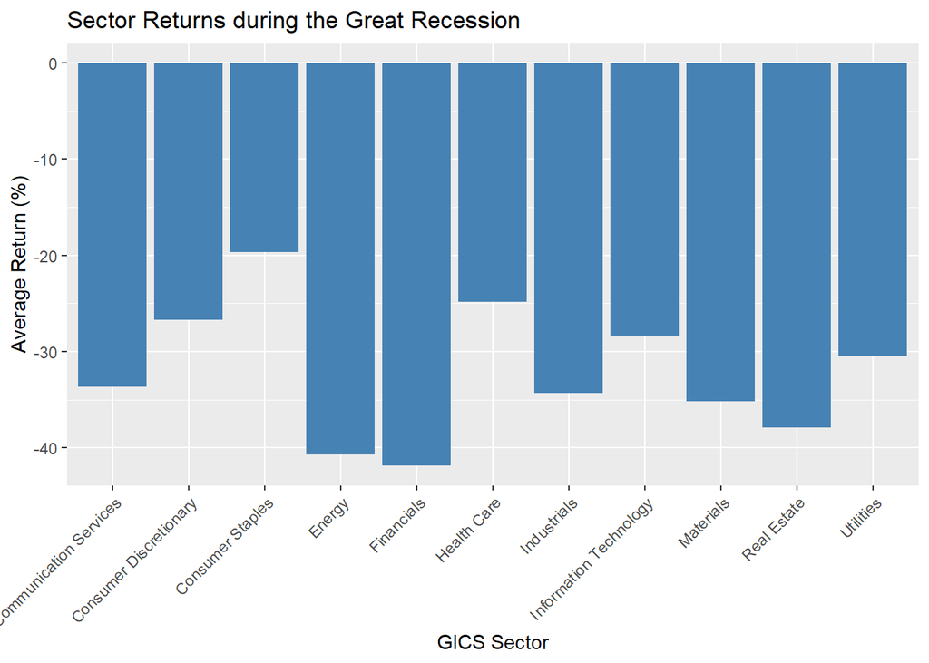

```r
# Create a function to plot sector returns
plot_sector_returns <- function(returns, title, color) {
  ggplot(returns, aes(x = GICS, y = avg_return)) +
    geom_bar(stat = "identity", fill = color) +
    labs(x = "GICS Sector", y = "Average Return (%)", title = title) +
    theme(axis.text.x = element_text(angle = 45, hjust = 1))
}

# Plot sector returns for each event
plot_sector_returns(recession_returns_close, "Sector Returns during the Great Recession", "steelblue")
```

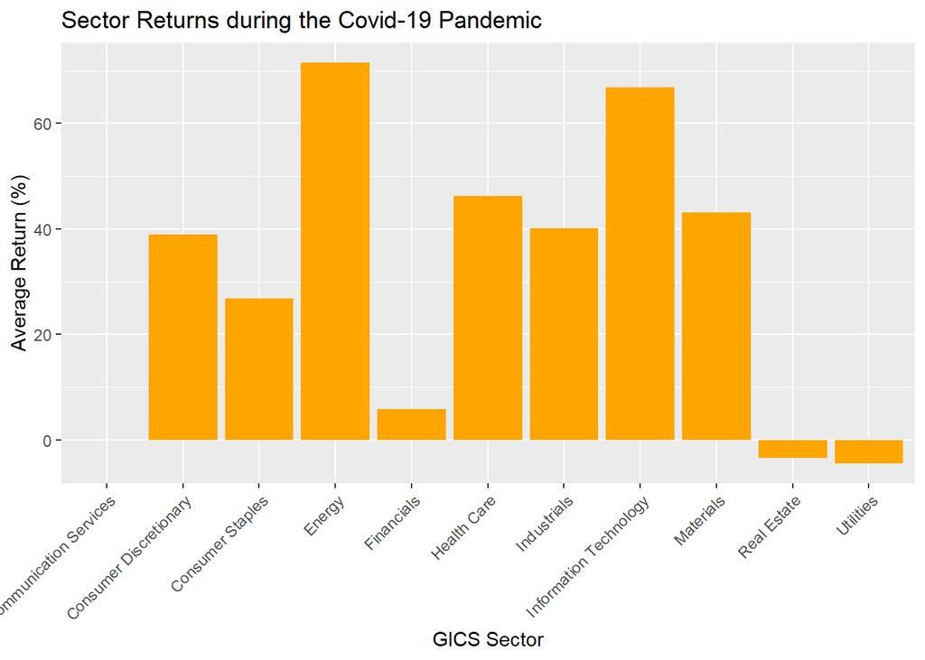

```r
plot_sector_returns(covid_returns_close, "Sector Returns during the Covid-19 Pandemic", "orange")
```

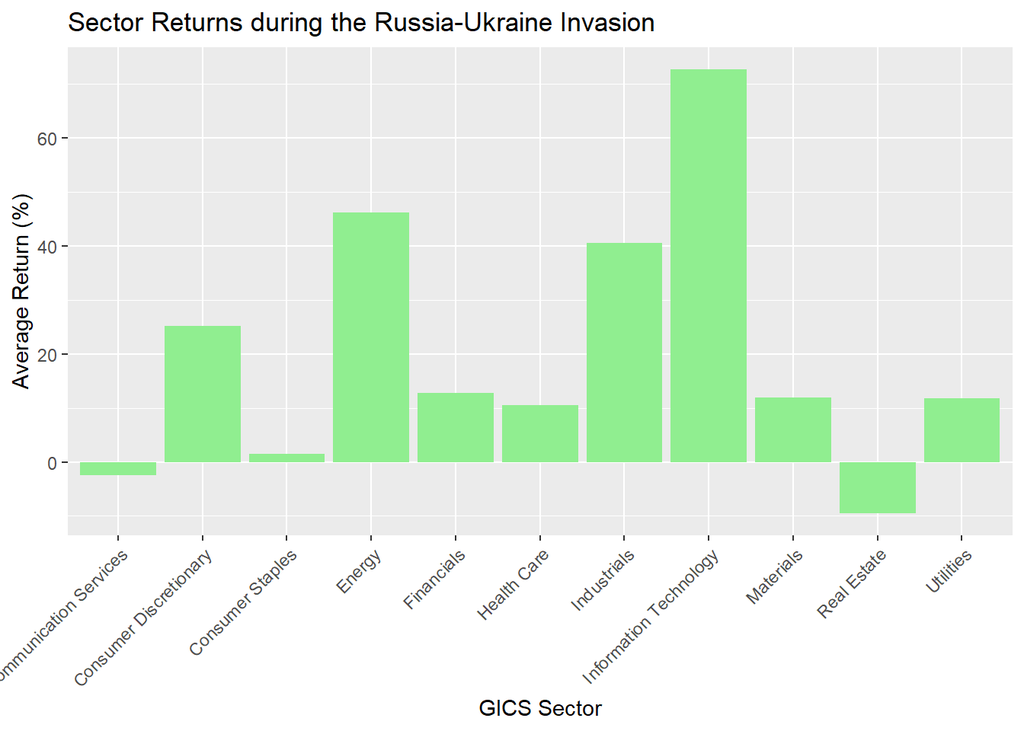

```r
plot_sector_returns(ukraine_returns_close, "Sector Returns during the Russia-Ukraine Invasion", "lightgreen")
```

# SMART Question 3: Can we develop a predictive model to forecast the S&P500 index?

## ARIMA Model for Forecasting

### Data Loading

```r
work_df$daily_change <- (work_df$Close / lag(work_df$Close) - 1) * 100
head(work_df)
```

```
##         Date Open High Low Close   Volume daily_change
## 1 2003-01-02  880  909 880   909 1.23e+09           NA
## 2 2003-01-03  909  911 903   909 1.13e+09      -0.0484
## 3 2003-01-06  909  932 909   929 1.44e+09       2.2474
## 4 2003-01-07  929  931 920   923 1.55e+09      -0.6545
## 5 2003-01-08  923  923 908   910 1.47e+09      -1.4086
## 6 2003-01-09  910  928 910   928 1.56e+09       1.9386
```

```r
work_df <- na.omit(work_df)
head(work_df)
```

```
##         Date Open High Low Close   Volume daily_change
## 2 2003-01-03  909  911 903   909 1.13e+09      -0.0484
## 3 2003-01-06  909  932 909   929 1.44e+09       2.2474
## 4 2003-01-07  929  931 920   923 1.55e+09      -0.6545
## 5 2003-01-08  923  923 908   910 1.47e+09      -1.4086
## 6 2003-01-09  910  928 910   928 1.56e+09       1.9386
## 7 2003-01-10  928  933 918   928 1.49e+09       0.0000
```

### Check if the time series is Stationary.

```r
adf.test(work_df$Close)
```

```
##
##  Augmented Dickey-Fuller Test
##
## data:  work_df$Close
## Dickey-Fuller = -1, Lag order = 17, p-value = 0.8
## alternative hypothesis: stationary
```

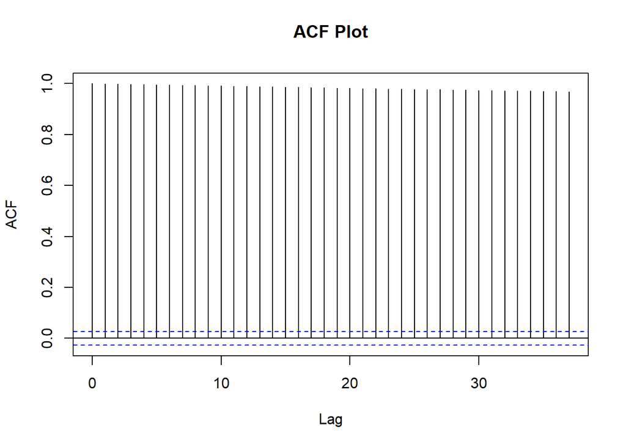

```r
# Check the stationarity using the ACF and PACF plots.
acf(work_df$Close, main = "ACF Plot")
```

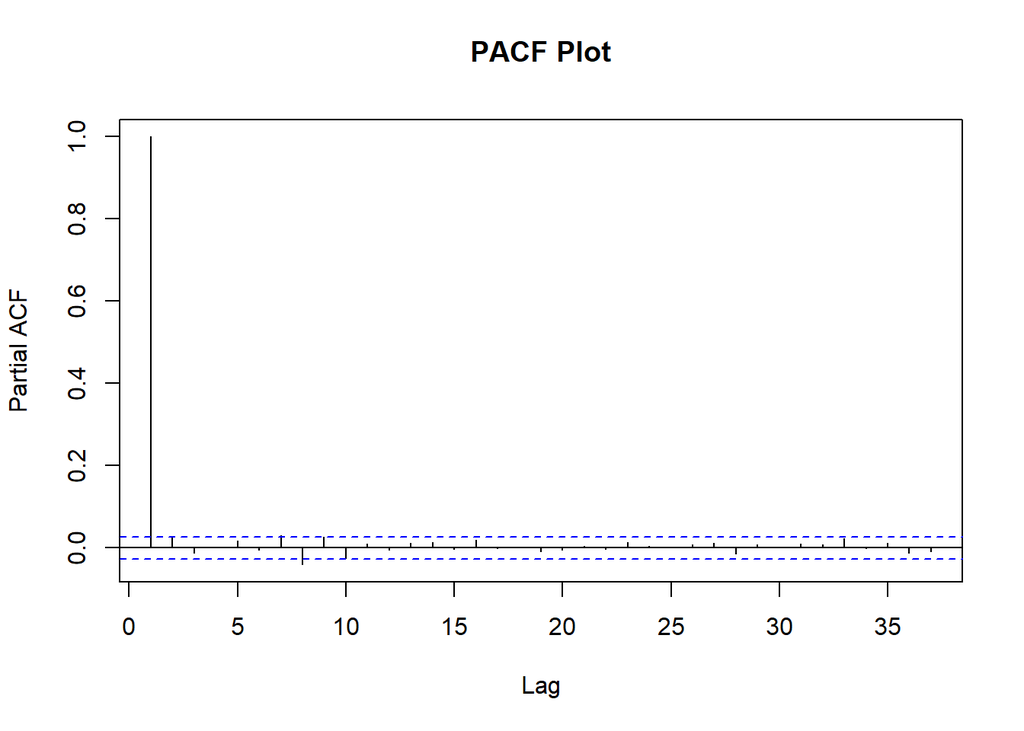

```r
pacf(work_df$Close, main = "PACF Plot")
```

- As we can see that the data is not stationary, let’s use first order differencing to address this issue.

### Making the time series data stationary

Using first order differencing to make the time series data stationary.

```r
ts_data <- xts(work_df$Close, order.by = work_df$Date)
```

### ADF test for the original time series data.

```r
adf.test(ts_data)
```

```
##
##  Augmented Dickey-Fuller Test
##
## data:  ts_data
## Dickey-Fuller = -1, Lag order = 17, p-value = 0.8
## alternative hypothesis: stationary
```

```r
diff_ts_data <- diff(ts_data, differences = 1)
diff_ts_data <- na.omit(diff_ts_data)
```

### ADF test for the differenced time series data.

```r
adf.test(diff_ts_data)
```

```
##
##  Augmented Dickey-Fuller Test
##
## data:  diff_ts_data
## Dickey-Fuller = -17, Lag order = 17, p-value = 0.01
## alternative hypothesis: stationary
```

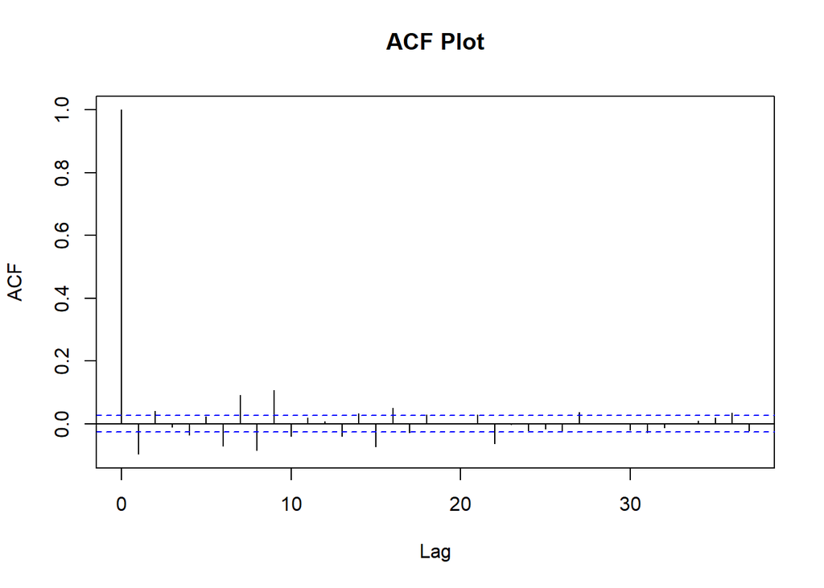

```r
acf(diff_ts_data, main = "ACF Plot")
```

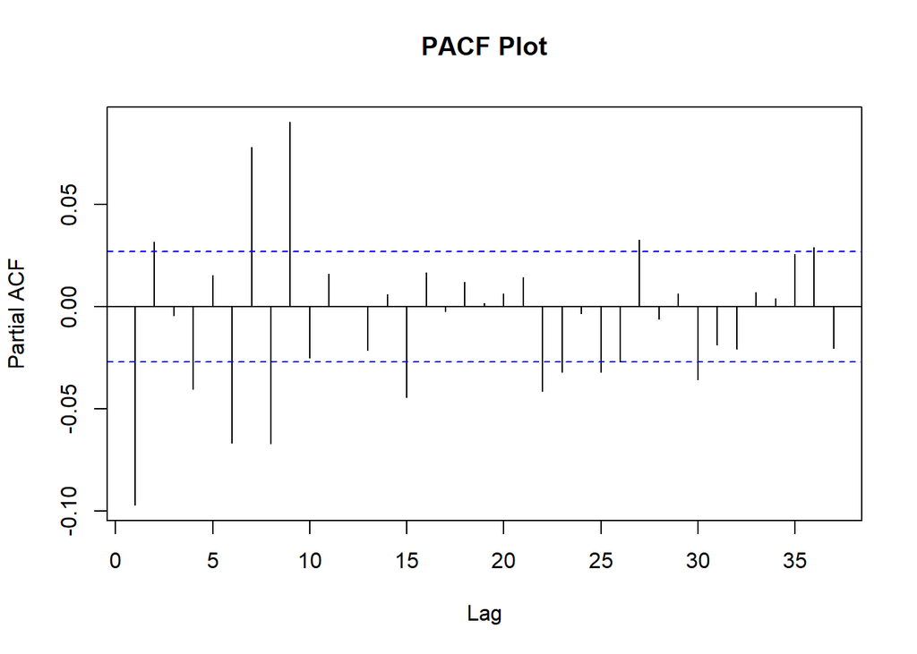

```r
pacf(diff_ts_data, main = "PACF Plot")
```

## ARIMA model fitting and forecasting

From the adf test and ACF and PACF plots, we can see that the time series data is close to stationarity. We can now create a baseline ARIMA model and forecast the future values.

```r
train_data <- head(diff_ts_data, n = round(0.98 * length(diff_ts_data)))
test_data <- diff_ts_data[-seq_along(train_data)]
arima_model <- auto.arima(train_data)
summary(arima_model)
```

```
## Series: train_data
## ARIMA(2,0,2) with non-zero mean
##
## Coefficients:
##          ar1     ar2    ma1    ma2   mean
##       -1.750  -0.878  1.681  0.792  0.707
## s.e.   0.022   0.021  0.029  0.027  0.340
##
## sigma^2 = 655:  log likelihood = -24129
## AIC=48269   AICc=48269   BIC=48308
##
## Training set error measures:
##                   ME RMSE  MAE MPE MAPE  MASE    ACF1
## Training set 0.00406 25.6 15.5 NaN  Inf 0.673 -0.0079
```

```r
forecasts <- forecast(arima_model, h = length(test_data))
```

### Evaluation of the ARIMA model

```r
# Convert the forecasts to the original scale.
last_train_date <- index(tail(train_data, 1))
last_observed_value <- ts_data[last_train_date]
actual_preds <- as.vector(last_observed_value) + cumsum(forecasts$mean)
actual_test <- as.vector(last_observed_value) + cumsum(test_data)
actual_preds <- xts(actual_preds, order.by = index(actual_test))
# Compute the forecasting errors
errors <- actual_preds - actual_test
# Calculate evaluation metrics
mae <- mean(abs(errors))
mse <- mean(errors^2)
rmse <- sqrt(mse)
```

Mean Absolute Error (MAE): 194.797

Mean Squared Error (RMSE): 228.446

- These are not the best scores when it comes to forecasting the S&P500 index.
- This behaviour is expected as the ARIMA model predicts purely based on the previous `Close` values without any other context.
- So, let’s try other models like LSTM to see if we can get better results.

### Plots

#### Plot train and test data.

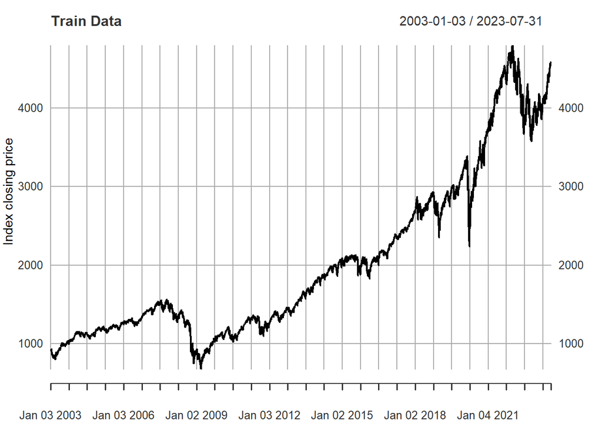

```r
plot(ts_data[index(ts_data) <= last_train_date], type = "l", xlab = "Time", ylab = "Index closing price", main = "Train Data")
```

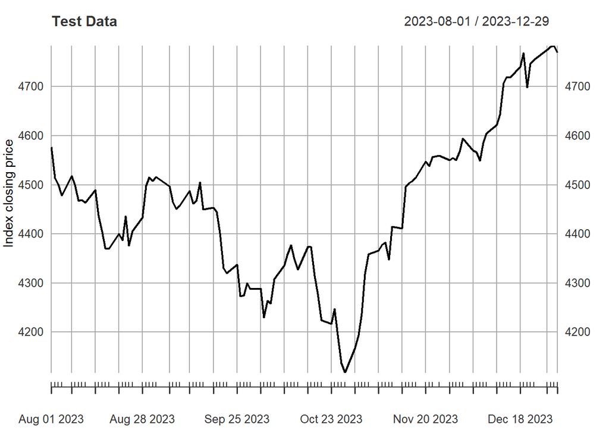

```r
plot(ts_data[index(ts_data) > last_train_date], type = "l", xlab = "Time", ylab = "Index closing price", main = "Test Data")
```

### Plot the forecasted data along with the train and test data.

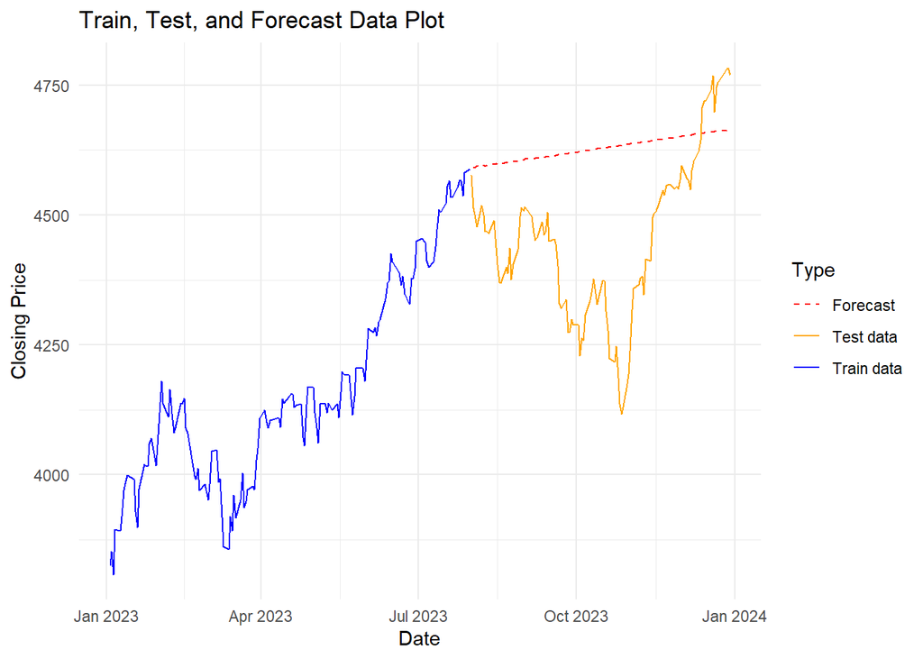

```r
plot_start_date <- as.Date("2023-01-01")
actual_train <- ts_data[index(ts_data) > plot_start_date & index(ts_data) <= last_train_date]
# Convert the time series data to data frames
train_df <- data.frame(Date = index(actual_train), Value = coredata(actual_train), Type = "Train data")
test_df <- data.frame(Date = index(actual_test), Value = coredata(actual_test), Type = "Test data")
forecast_df <- data.frame(Date = index(actual_preds)[-1], Value = actual_preds[-1], Type = "Forecast")
# Combine the data frames
combined_df <- rbind(train_df, test_df, forecast_df)
# Create the plot
ggplot(combined_df, aes(x = Date, y = Value, color = Type, linetype = Type)) +
  geom_line() +
  labs(title = "Train, Test, and Forecast Data Plot",
       x = "Date",
       y = "Closing Price") +
  scale_color_manual(values = c("red", "orange", "blue")) +
  scale_linetype_manual(values = c("dashed", "solid", "solid")) +
  theme_minimal() +
  theme(legend.position = "right")
```